# Comparativo entre bases de dados disponibilizadas na CGU

Órgãos e entidades do poder Executivo

```r
library(tidyverse)
library(here)
library(glue)
library(lubridate)
`%notin%` <- function(x, y) !(x %in% y)
```

```r
# aplica identidade visual da TB/AeP:
source(here("src/0-paleta-de-cores.R"), encoding = "UTF-8")

theme_set(theme_minimal())

theme_update(
  panel.grid.minor = element_blank(),
  panel.background = element_rect(fill = cores_tb[["cinza_quase_branco"]],
                                  color = "transparent")
)
```

## Quais são as bases de dados disponilizadas no Portal FalaBR?

- Base de dados da CGU com pedidos e respostas [clique aqui](http://www.consultaesic.cgu.gov.br/busca/_layouts/15/DownloadPedidos/DownloadDados.aspx)
  - Esses dados vão de 2015 até 2021 e possuem os campos de texto dos pedidos, das resposta e dos recursos completos.
- Dase de dados do [painel da cgu](http://paineis.cgu.gov.br/lai/index.htm), disponível para download [neste link](https://falabr.cgu.gov.br/publico/DownloadDados/DownloadDadosLai.aspx)
  - Esses dados vão de 2012 até 2021 mas não possuem os campos de texto dos pedidos, das respostas e dos recursos.

## Comparativos

Existe uma defasagem entre a base do [painel CGU](https://falabr.cgu.gov.br/publico/DownloadDados/DownloadDadosLai.aspx) e a [base com pedidos e respostas completas](http://www.consultaesic.cgu.gov.br/busca/_layouts/15/DownloadPedidos/DownloadDados.aspx).

> Qual o motivo dessa diferença entre as duas bases?

```r
pedidos_painel <- "dados/load/rds/base-cgu.rds" %>%
  here() %>%
  readRDS() %>%
  pluck("pedidos") %>%
  janitor::clean_names() %>%
  mutate(
    ts_registro = data_registro,
    ts_resposta = data_resposta,
    data_registro = dmy(data_registro) %>% floor_date(unit = "month"),
    data_resposta = dmy(data_resposta) %>% floor_date(unit = "month")) %>%
  rename(orgao = orgao_destinatario) %>%
  filter(!is.na(decisao), !is.na(data_resposta))

pedidos_cgu <- "dados/load/rds/pedidos-cgu.rds" %>%
  here() %>%
  readRDS() %>%
  rename(orgao = orgaodestinatario)
```

```r
painel <- pedidos_painel %>%
  mutate(is_pedido_de_informacao = case_when(
    decisao %notin% c(
      "Pergunta Duplicada/Repetida",
      "Não se trata de solicitação de informação"
    ) ~ "Pedidos de acesso a informação via LAI",
    TRUE ~ decisao
  ) %>% str_wrap(25)) %>%
  count(data_registro,
        is_pedido_de_informacao,
        name = "qt",
        base = "Base de dados extraída do Fala.br")

cgu <- pedidos_cgu %>%
  mutate(is_pedido_de_informacao = case_when(
    decisao %notin% c(
      "Pergunta Duplicada/Repetida",
      "Não se trata de solicitação de informação"
    ) ~ "Pedidos de acesso a informação via LAI",
    TRUE ~ decisao
  ) %>% str_wrap(25)) %>%
  count(data_registro,
        is_pedido_de_informacao,
        name = "qt",
        base = "Base de dados extraída da\nBusca de Pedidos e Respostas")

# bind_rows(painel, cgu) %>%
#   filter(is_pedido_de_informacao == "Pedidos de acesso a\ninformação via LAI") %>%
#   ggplot(aes(x = data_registro, y = qt, color = base)) +
#   geom_line(size = 1)  +
#   geom_vline(xintercept = seq(ymd('2012-01-01'), ymd('2022-01-01'), by = 'year'), lty = 3) +
#   theme_minimal() +
#   labs(
#     title = "Comparação entre as duas bases de dados disponíveis no FalaBR",
#     caption = "Painel CGU: https://falabr.cgu.gov.br/publico/DownloadDados/DownloadDadosLai.aspx\nBase com tetos de pedidos: http://www.consultaesic.cgu.gov.br/busca/_layouts/15/DownloadPedidos/DownloadDados.aspx",
#     x = "Mês do registro",
#     y = "Quantidade de manifestações",
#     color = NULL
#   ) +
#   theme(legend.position = "top")
```

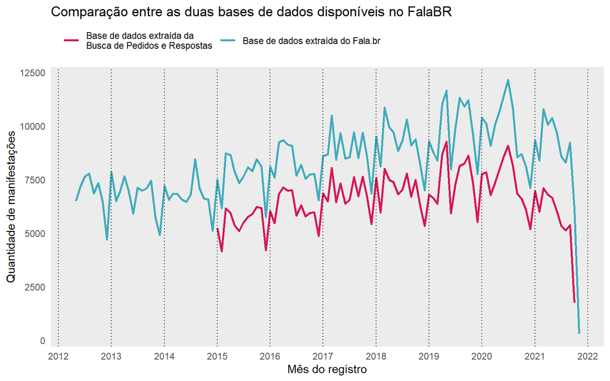

```r
bind_rows(painel, cgu) %>%
  filter(is_pedido_de_informacao == "Pedidos de acesso a\ninformação via LAI") %>%
  ggplot(aes(x = data_registro, y = qt, color = base)) +
  geom_line(size = 1)  +
  geom_vline(xintercept = seq(ymd('2012-01-01'), ymd('2022-01-01'),
                              by = 'year'), lty = 3) +
  scale_color_manual(values = c(cores_aep[["rosa"]], cores_tb[["azul"]])) +
  scale_x_date(date_breaks = "year", date_labels = "%Y") +
  labs(
    title = "Comparação entre as duas bases de dados disponíveis no FalaBR",
    x = "Mês do registro",
    y = "Quantidade de manifestações",
    color = NULL
  ) +
  theme(legend.position = "top",
        legend.justification = "left")
```

### Dados da Caixa Econômica Federal

```r
painel <- pedidos_painel %>%
  filter(str_detect(orgao, "^CEF ")) %>%
  mutate(is_pedido_de_informacao = case_when(
    decisao %notin% c(
      "Pergunta Duplicada/Repetida",
      "Não se trata de solicitação de informação"
    ) ~ "Pedidos de acesso a informação via LAI",
    TRUE ~ decisao
  ) %>% str_wrap(25)) %>%
  count(data_registro, is_pedido_de_informacao,
        name = "qt",
        base = "Base de dados extraída do Fala.br")

cgu <- "dados/load/rds/pedidos-cgu.rds" %>%
  here() %>%
  readRDS() %>%
  rename(orgao = orgaodestinatario) %>%
  filter(str_detect(orgao, "^CEF ")) %>%
  mutate(is_pedido_de_informacao = case_when(
    decisao %notin% c(
      "Pergunta Duplicada/Repetida",
      "Não se trata de solicitação de informação"
    ) ~ "Pedidos de acesso a informação via LAI",
    TRUE ~ decisao
  ) %>% str_wrap(25)) %>%
  count(data_registro, is_pedido_de_informacao,
        name = "qt",
        base = "Base de dados extraída da\nBusca de Pedidos e Respostas")
```

Os dados da Caixa Econômica Federal também não estão disponibilizados por completo na base [com pedidos e respostas completas](http://www.consultaesic.cgu.gov.br/busca/_layouts/15/DownloadPedidos/DownloadDados.aspx)

```r
qt_cef <- painel %>%
  filter(year(data_registro) <= 2019) %>%
  count(is_pedido_de_informacao, wt = qt) %>% deframe()
```

```r
# bind_rows(painel, cgu) %>%
#   filter(is_pedido_de_informacao == "Pedidos de acesso a\ninformação via LAI") %>%
#   ggplot(aes(x = data_registro, y = qt, color = base)) +
#   geom_line(size = 1)  +
#   geom_vline(xintercept = seq(ymd('2012-01-01'), ymd('2022-01-01'), by = 'year'), lty = 3) +
#   geom_text(
#     data = . %>% filter(month(data_registro) == 2),
#     aes(label = year(data_registro), y = -200),
#     size = 3.5,
#     vjust = 1.3,
#     hjust = .25,
#     color = "gray20",
#     show.legend = F
#   ) +
#   theme_minimal() +
#   labs(
#     title = "CEF - Caixa Econômica Federal",
#     subtitle = "Comparação entre as duas bases de dados disponíveis no FalaBR",
#     caption = "Painel CGU: https://falabr.cgu.gov.br/publico/DownloadDados/DownloadDadosLai.aspx\nBase com tetos de pedidos: http://www.consultaesic.cgu.gov.br/busca/_layouts/15/DownloadPedidos/DownloadDados.aspx",
#     x = "Mês do registro",
#     y = "Quantidade de manifestações",
#     color = NULL
#   ) +
#   theme(legend.position = "top")
```

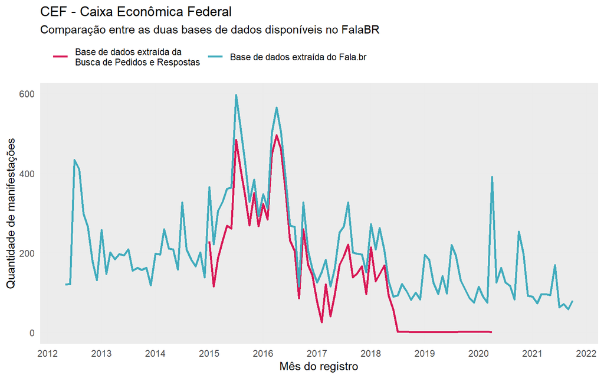

```r
bind_rows(painel, cgu) %>%
  filter(is_pedido_de_informacao == "Pedidos de acesso a\ninformação via LAI") %>%
  ggplot(aes(x = data_registro, y = qt, color = base)) +
  geom_line(size = 1)  +
  # geom_vline(xintercept = seq(ymd('2012-01-01'), ymd('2022-01-01'),
  #                             by = 'year'), lty = 3) +
  scale_color_manual(values = c(cores_aep[["rosa"]], cores_tb[["azul"]])) +
  scale_x_date(date_breaks = "year", date_labels = "%Y") +
  labs(
    title = "CEF - Caixa Econômica Federal",
    subtitle = "Comparação entre as duas bases de dados disponíveis no FalaBR",
    x = "Mês do registro",
    y = "Quantidade de manifestações",
    color = NULL
  ) +
  theme(legend.position = "top",
        legend.justification = "left")
```

Comparação por decisão que caracteriza pedido de informação LAI

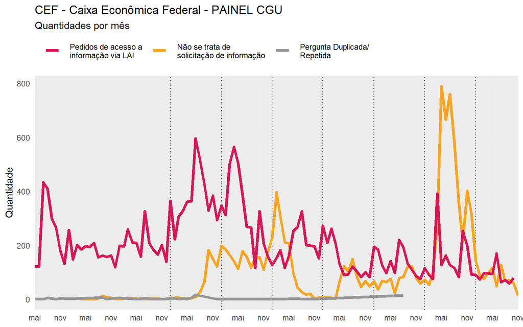

```r
pedidos_painel %>%
  filter(str_detect(orgao, "^CEF –")) %>%
  mutate(is_pedido_de_informacao = case_when(
    decisao %notin% c(
      "Pergunta Duplicada/Repetida",
      "Não se trata de solicitação de informação"
    ) ~ "Pedidos de acesso a informação via LAI",
    TRUE ~ decisao
  ) %>% str_wrap(25)) %>%
  count(data_registro, orgao, is_pedido_de_informacao) %>%
  group_by(is_pedido_de_informacao) %>%
  #mutate(n = zoo::rollapply(n, 3, mean, align = 'right', fill = NA)) %>%
  ggplot(aes(x = data_registro, y = n, color = is_pedido_de_informacao)) +
  geom_vline(xintercept = seq(ymd('2015-01-01'), ymd('2022-01-01'), by = 'year'), lty = 3) +
  geom_line(size = 1.5) +
  scale_fill_manual(values = cores_lai) +
  scale_color_manual(values = cores_lai, breaks = names(cores_lai)[c(3,1,2)]) +
  scale_x_date(
    breaks = scales::date_breaks("6 months"),
    date_labels = "%b",
    expand = c(0, 0)) +
  labs(
    y = "Quantidade",
    x = NULL,
    fill = NULL,
    color = NULL,
    title = "CEF - Caixa Econômica Federal - PAINEL CGU",
    subtitle = "Quantidades por mês"
  ) +
  #theme_minimal() +
  theme(legend.position = "top",
        legend.justification = "left",
        legend.text = element_text(margin = margin(2, 5, 2, 5, "pt")))
```

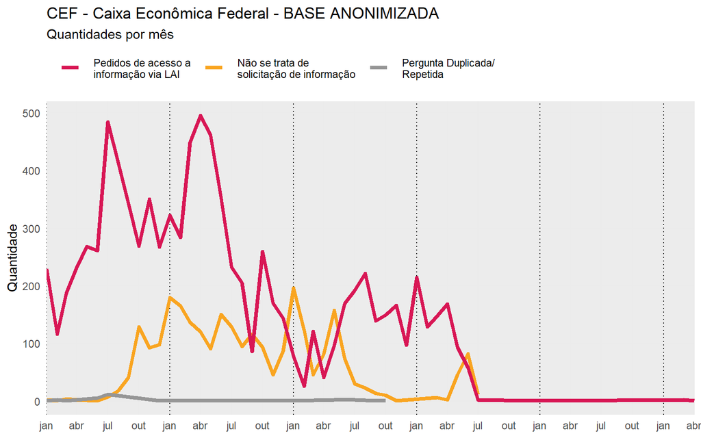

```r
pedidos_cgu %>%
  filter(str_detect(orgao, "^CEF –")) %>%
  mutate(is_pedido_de_informacao = case_when(
    decisao %notin% c(
      "Pergunta Duplicada/Repetida",
      "Não se trata de solicitação de informação"
    ) ~ "Pedidos de acesso a informação via LAI",
    TRUE ~ decisao
  ) %>% str_wrap(25)) %>%
  count(data_registro, orgao, is_pedido_de_informacao) %>%
  #mutate(n = zoo::rollapply(n, 3, mean, align = 'right', fill = NA)) %>%
  ggplot(aes(x = data_registro, y = n, color = is_pedido_de_informacao)) +
  geom_vline(xintercept = seq(ymd('2015-01-01'), ymd('2022-01-01'), by = 'year'), lty = 3) +
  geom_line(size = 1.5) +
  scale_fill_manual(values = cores_lai) +
  scale_color_manual(values = cores_lai, breaks = names(cores_lai)[c(3,1,2)]) +
  scale_x_date(
    breaks = scales::date_breaks("3 months"),
    date_labels = "%b",
    expand = c(0, 0)) +
  labs(
    y = "Quantidade",
    x = NULL,
    fill = NULL,
    color = NULL,
    title = "CEF - Caixa Econômica Federal - BASE ANONIMIZADA",
    subtitle = "Quantidades por mês"
  ) +
  #theme_minimal() +
  theme(legend.position = "top",
        legend.justification = "left",
        legend.text = element_text(margin = margin(2, 5, 2, 5, "pt")))
```

### Comparação entre percentual de pedidos

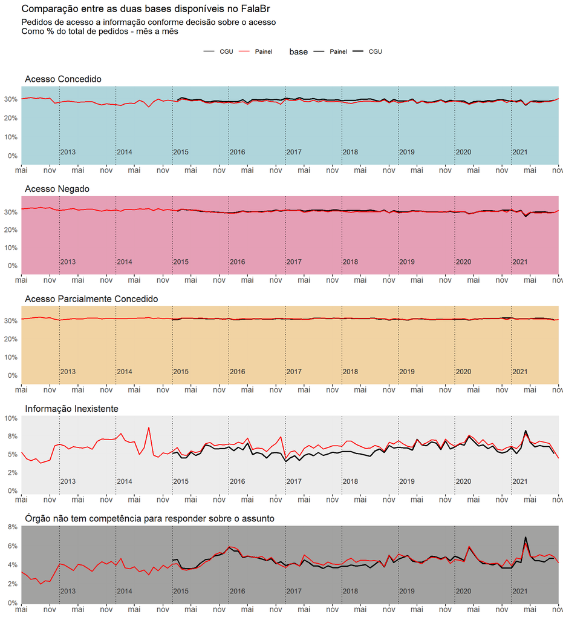

```r
painel <- pedidos_painel %>%
  mutate(is_pedido_de_informacao = case_when(
    decisao %notin% c(
      "Pergunta Duplicada/Repetida",
      "Não se trata de solicitação de informação"
    ) ~ "Pedidos de acesso a informação via LAI",
    TRUE ~ decisao
  ) %>% str_wrap(25)) %>%
  filter(is_pedido_de_informacao ==  str_wrap("Pedidos de acesso a informação via LAI", 25)) %>%
  count(data_registro, decisao, name = "qt", base = "Painel")

cgu <- pedidos_cgu %>%
  mutate(is_pedido_de_informacao = case_when(
    decisao %notin% c(
      "Pergunta Duplicada/Repetida",
      "Não se trata de solicitação de informação"
    ) ~ "Pedidos de acesso a informação via LAI",
    TRUE ~ decisao
  ) %>% str_wrap(25)) %>%
  filter(is_pedido_de_informacao ==  str_wrap("Pedidos de acesso a informação via LAI", 25)) %>%
  count(data_registro, decisao, name = "qt", base = "CGU")

#painel <- painel %>% filter(data_registro >= unique(min(cgu$data_registro)))

p <- bind_rows(cgu, painel) %>%
  add_count(data_registro, base, wt = qt, name = "qt_mes") %>%
  mutate(per = qt / qt_mes) %>%
    mutate(per = zoo::rollapply(per, 3, mean, align = 'right', fill = NA))

p %>%
  ggplot(aes(x = data_registro, y = per, size = base, color = base)) +
  geom_rect(
    data = . %>%
      filter(data_registro == min(data_registro) | data_registro == max(data_registro)),
    aes(
      xmin = min(data_registro),
      xmax = max(data_registro),
      ymin = -Inf,
      ymax = Inf,
      fill = decisao
    ),
    alpha = .2,
    color = "transparent",
    show.legend = F
  ) +
  geom_line() +
  scale_fill_manual(values = cores_decisao) +
  scale_color_manual(values = c("CGU" = "black", "Painel" = "red")) +
  scale_size_manual(values = c("Painel" = .6, "CGU" = .75)) +
  hrbrthemes::scale_y_percent(expand = c(0.2, 0)) +
  scale_x_date(
    breaks = scales::date_breaks("6 months"),
    date_labels = "%b",
    expand = c(0, 0)
  ) +
  #theme_minimal() +
  theme(
    legend.position = "top",
    axis.ticks.x = element_line(),
    legend.text = element_text(size = 8),
    axis.text.x = element_text(size = 10, vjust = 2.5, hjust = .5),
    panel.grid.minor = element_blank(),
    strip.text = element_text(size = 12, angle = 0, hjust = 0)
  ) +
  geom_vline(xintercept = seq(ymd('2013-01-01'), ymd('2021-01-01'), by = 'year'), lty = 3) +
  geom_text(
    data = . %>% filter(month(data_registro) == 2),
    aes(label = year(data_registro), y = .01),
    size = 3,
    vjust = .1,
    hjust = .25,
    color = "gray20"
  ) +
  labs(
    x = NULL,
    y = NULL,
    title = "Comparação entre as duas bases disponíveis no FalaBr",
    subtitle = "Pedidos de acesso a informação conforme decisão sobre o acesso\nComo % do total de pedidos - mês a mês",
    color = NULL,
    fill = NULL,
    lty = NULL
  ) +
  facet_wrap(~ reorder(decisao, -qt), scales = 'free', ncol = 1)
```

### Comparação do total de pedidos

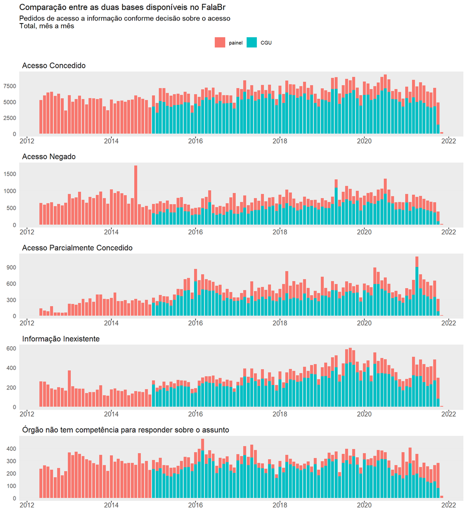

```r
p %>%
  pivot_wider(c(1, 2), names_from = base, values_from = qt) %>%
  # filter(is.na(CGU))
  transmute(
    data_registro,
    decisao,
    CGU = replace_na(CGU, 0),
    painel = Painel - CGU) %>%
  pivot_longer(-c(data_registro, decisao), names_to = "base", values_to = "qt") %>%
  ggplot(aes(x = data_registro, y = qt, fill = reorder(base, qt))) +
  geom_col() +
  facet_wrap(~ reorder(decisao, -qt), scales = 'free', ncol = 1) +
  #theme_minimal() +
  theme(
    legend.position = "top",
    axis.ticks.x = element_line(),
    legend.text = element_text(size = 8),
    axis.text.x = element_text(size = 10, vjust = 2.5, hjust = .5),
    panel.grid.minor = element_blank(),
    strip.text = element_text(size = 12, angle = 0, hjust = 0)
  ) +
  labs(
    x = NULL,
    y = NULL,
    title = "Comparação entre as duas bases disponíveis no FalaBr",
    subtitle = "Pedidos de acesso a informação conforme decisão sobre o acesso\nTotal, mês a mês",
    color = NULL,
    fill = NULL,
    lty = NULL
  )
```